# Mack Creek Vertebrates

Waldo and Wes

11/26/2019

## Data and Methods

The data used in this analysis is from an aquatic vertebrate population study conducted in the H.J. Andrews Experimental Forest at Mack Creek, OR. Since 1993, the study has included length and weight measurements of Pacific Giant Salamanders as well as information about the environment where these samples were taken. The environmental data includes specific habitat information (pool, cascade, or side channels) and historical habitat data (clear cut forest vs old growth). Using preliminary data exploration methods such as QQ-plots and Levene’s test for equality of variances, this report was able to determine whether parametric tests (T-test and ANOVA) were most appropriate for identifying significant difference among the collected samples. RStudio Version 1.2.1335 was used to conduct the statistical tests with a significance level of p < 0.05.

[figure not shown]

*Image from Google Maps*

Citation: Gregory S. V. 2016. Aquatic Vertebrate Population Study in Mack Creek, Andrews Experimental Forest, 1987 to present. Environmental Data Initiative. https://doi.org/10.6073/pasta/5de64af9c11579266ef20da2ff32f702. Dataset accessed 11/19/2019.

## Results

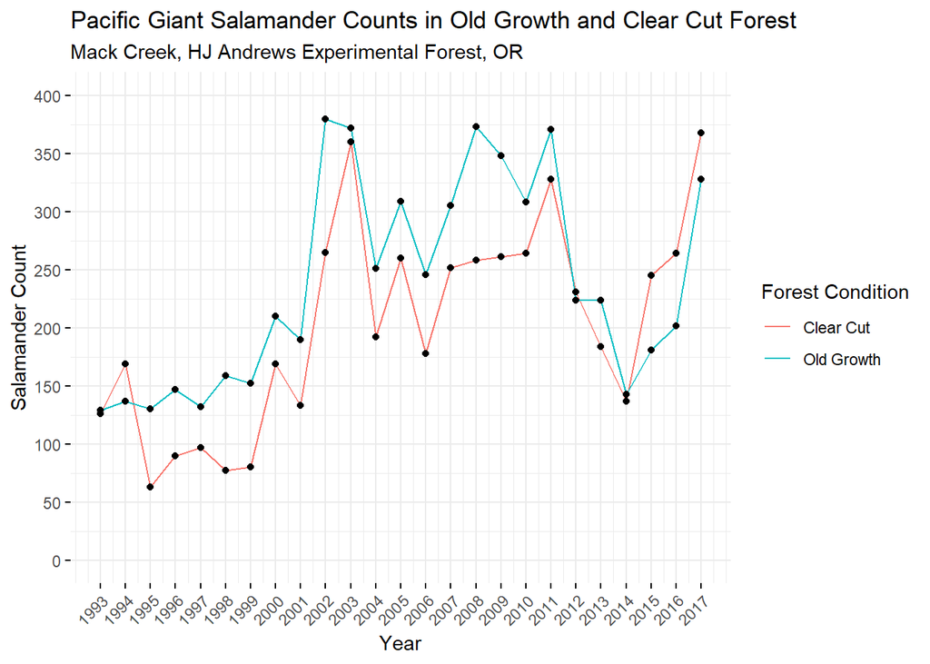

**Figure 1** *Salamander counts were recorded in both clear-cut and old-growth forests abutting Mack Creek for 25 years.*

| Forest Condition | Cascade | Pool | Side Channel |
| --- | --- | --- | --- |
| Clear Cut | 67% | 8% | 24% |
| Old Growth | 63% | 14% | 23% |

**Figure 2.** *Proportion of salamanders found in different stream types within clear-cut and old-growth forests during 2017.*

Forest conditions do not affect the proportion of salamanders found in cascades, pools, or side channels. ($\chi$<sup>2</sup>(2) = 5.54, p = 0.063).

### Is there a significant difference in average weight between salamanders found in different forest environments?

Let’s compare weights of Pacific giant salamanders in clear cut and old growth forest sections of the creek in 2017.

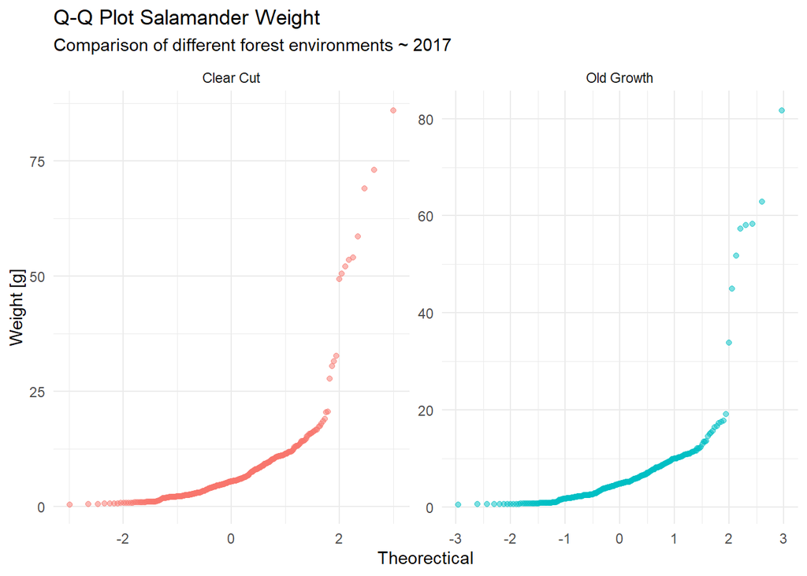

**Figure 3.** *Although data is not normally distrubted (lack of linear relationship), both plots look like they could have similar variance*

These plots do not show a linear relationship between the actual distribution of the data and the theoretical normal dsitrbution. Therefore, we can conclude that the data is not normally distributed and an equal varaiance test will be necessary to determine what statistical test is most appropriate.

```
## Levene's Test for Homogeneity of Variance (center = median)
##        Df F value Pr(>F)
## group   1  1.1004 0.2945
##       693
```

The Levene equal variance test does not detect a significant difference in variance. As indicated by the p-value of 0.29, we do not have significant evidence to reject the null hypothesis that variance among these datasets are the same. Since variance is equal among the samples we can conduct a t-test to check for a significant difference in means.

```
##
##  Welch Two Sample t-test
##
## data:  MC_og_sample$weight and MC_cc_sample$weight
## t = -1.6669, df = 692.79, p-value = 0.09599
## alternative hypothesis: true difference in means is not equal to 0
## 95 percent confidence interval:
##  -2.5972032  0.2121307
## sample estimates:
## mean of x mean of y
##  6.583333  7.775870
```

The t-test results (p-value = 0.1) fail to reject the null hypothesis. This implies that there is not a significant difference in average weight between the two salamander groups.

### Is Pacific giant salamander weight significantly different among various water environments?

Let’s compare the weights of Pacific giant salamanders grouped by their location (cascasde, side channel, pool) in 2017.

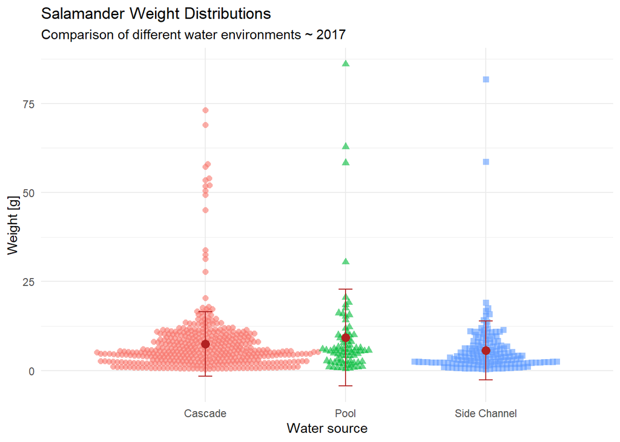

**Figure 4.** *This plot shows the weight distribution among the three factor levels. The error bars are centered about the respective mean and error is represented as $\pm$ one standard deviation.*

This beewswarm plot reveals the skew of the data. Most of the captured salamanders are small with a few quite large outliers.

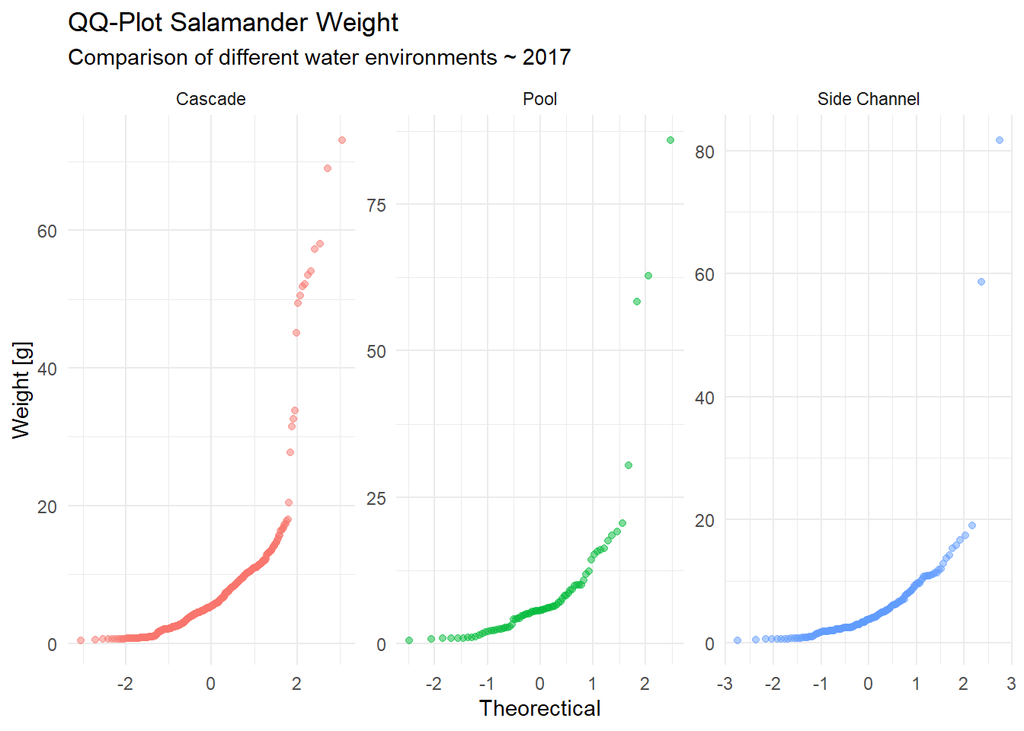

**Figure 5.** *Similar to the previous Q-Q plot, this figure shows a non-normal distribution.*

Because data is not normally distributed, to proceed with a parametric test we first need to check for a significant difference in variances.

```
## Levene's Test for Homogeneity of Variance (center = median)
##        Df F value  Pr(>F)
## group   2  2.3883 0.09255 .
##       684
## ---
## Signif. codes:  0 '***' 0.001 '**' 0.01 '*' 0.05 '.' 0.1 ' ' 1
```

Levene’s Test does not detect a significant difference in variances (p-value = 0.09). This means we can proceed with an ANOVA test.

```
##              Df Sum Sq Mean Sq F value Pr(>F)
## river_type    2    757   378.4   4.216 0.0151 *
## Residuals   684  61403    89.8
## ---
## Signif. codes:  0 '***' 0.001 '**' 0.01 '*' 0.05 '.' 0.1 ' ' 1
## 1 observation deleted due to missingness
```

The ANOVA test detects a significant difference (p-value < 0.05) in mean weight, but we need to use Tukey’s HSD to find which group pairing differs.

```
##   Tukey multiple comparisons of means
##     95% family-wise confidence level
##
## Fit: aov(formula = weight ~ river_type, data = MC_rtype_17)
##
## $river_type
##                           diff        lwr        upr     p adj
## Pool-Cascade          1.776650 -0.9846147  4.5379145 0.2862119
## Side Channel-Cascade -1.844204 -3.8759182  0.1875106 0.0841989
## Side Channel-Pool    -3.620854 -6.7089770 -0.5327303 0.0166225
```

Tukey’s HSD reveals that the significant difference in mean weight is only between salamanders collected from pools and the side channel area. Lastly, an effect size test is necessary to strength the validity of our conclusion.

```
##
## Cohen's d
##
## d estimate: -0.3529066 (small)
## 95 percent confidence interval:
##       lower       upper
## -0.62810479 -0.07770845
```

Cohen’s D shows a small effect size (-0.35) incresaing our confidence in data results. Unfortunately these results are based in parametric tests that focus on comparing means. Because weight is not normally distributed, means may not be the best representative measure of that data. Additonally, means are heavily influenced by outliers which are apparent in the Q-Q plots. Medians would be a better metric to compare as they take into the account the skew inherit in the weight distribution.